# ME731: Análise Discriminnate

Prof. Carlos Trucíos

## Case 1:

O *data set* MEDIFIS contém informações sobre diversas medidas físicas de homens (1) e mulheres (0). Estamos interessados em classificar pessoas por sexo, segundo as medidas físicas que elas apresentam.

> Os dados estão disponíveis [aqui](https://raw.githubusercontent.com/jvega68/EA3/master/datos/medifis.dat)

```r
library(MASS)
library(dplyr)
medifis <- read.table("https://raw.githubusercontent.com/jvega68/EA3/master/datos/medifis.dat")
glimpse(medifis)
```

```
Rows: 27
Columns: 8
$ V1 <int> 0, 1, 0, 0, 0, 0, 0, 1, 1, 0, 0, 1, 0, 1, …
$ V2 <dbl> 159, 164, 172, 167, 164, 161, 168, 181, 18…
$ V3 <dbl> 49, 62, 65, 52, 51, 67, 48, 74, 74, 50, 65…
$ V4 <dbl> 36, 39, 38, 37, 36, 38, 39, 43, 41, 36, 36…
$ V5 <dbl> 68.0, 73.0, 75.0, 73.0, 71.0, 71.0, 72.5, …
$ V6 <dbl> 42.0, 44.0, 48.0, 41.5, 44.5, 44.0, 41.0, …
$ V7 <dbl> 57.0, 55.0, 58.0, 58.0, 54.0, 56.0, 54.5, …
$ V8 <dbl> 40, 44, 44, 44, 40, 42, 43, 47, 47, 41, 41…
```

```r
colnames(medifis) <- c("sexo", "altura", "peso", "pe", "braco", "costas", "diam_craneo", "joelho")
glimpse(medifis)
```

```
Rows: 27
Columns: 8
$ sexo        <int> 0, 1, 0, 0, 0, 0, 0, 1, 1, 0, 0, 1, 0, …
$ altura      <dbl> 159, 164, 172, 167, 164, 161, 168, 181,…
$ peso        <dbl> 49, 62, 65, 52, 51, 67, 48, 74, 74, 50,…
$ pe          <dbl> 36, 39, 38, 37, 36, 38, 39, 43, 41, 36,…
$ braco       <dbl> 68.0, 73.0, 75.0, 73.0, 71.0, 71.0, 72.…
$ costas      <dbl> 42.0, 44.0, 48.0, 41.5, 44.5, 44.0, 41.…
$ diam_craneo <dbl> 57.0, 55.0, 58.0, 58.0, 54.0, 56.0, 54.…
$ joelho      <dbl> 40, 44, 44, 44, 40, 42, 43, 47, 47, 41,…
```

### EAD

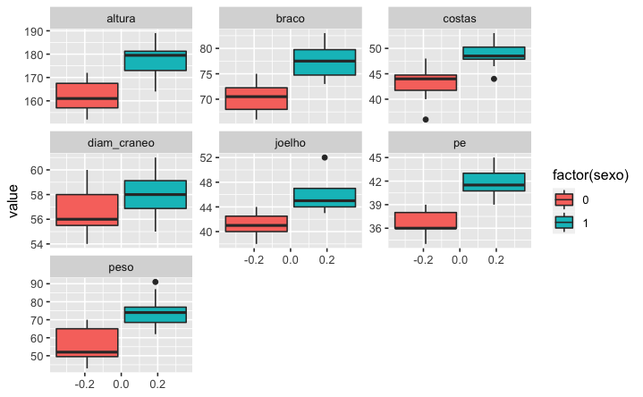

```r
library(tidyr)
library(ggplot2)
medifis %>% pivot_longer(!sexo, names_to = "variaveis") %>% ggplot() +
  geom_boxplot(aes(y = value, group = factor(sexo), fill = factor(sexo))) +
  facet_wrap(.~variaveis, scales = "free_y")
```

### Suposições:

```r
biotools::boxM(medifis[,-1], medifis$sexo)
```

```
    Box's M-test for Homogeneity of Covariance Matrices

data:  medifis[, -1]
Chi-Sq (approx.) = 39.871, df = 28, p-value = 0.06789
```

```r
mvnormalTest::mardia(medifis[medifis$sexo == 0, -1])
```

| Test | Statistic | p-value | Result |
| --- | --- | --- | --- |
| Skewness | 94.1646 | 0.2102 | YES |
| Kurtosis | 0.3299 | 0.7414 | YES |
| MV Normality | NA | NA | YES |

```
$uv.shapiro
            W      p-value UV.Normality
altura      0.9509 0.5383  Yes
peso        0.8966 0.0845  Yes
pe          0.8904 0.068   Yes
braco       0.94   0.3821  Yes
costas      0.9515 0.5477  Yes
diam_craneo 0.9602 0.6951  Yes
joelho      0.9475 0.4865  Yes
```

```r
mvnormalTest::mardia(medifis[medifis$sexo == 1, -1])
```

| Test | Statistic | p-value | Result |
| --- | --- | --- | --- |
| Skewness | 102.0074 | 0.0883 | YES |
| Kurtosis | 0.4262 | 0.67 | YES |
| MV Normality | NA | NA | YES |

```
$uv.shapiro
            W      p-value UV.Normality
altura      0.9613 0.8028  Yes
peso        0.9453 0.5702  Yes
pe          0.9602 0.7868  Yes
braco       0.9215 0.2984  Yes
costas      0.9567 0.7361  Yes
diam_craneo 0.9822 0.9909  Yes
joelho      0.8495 0.0362  No
```

### Análise Discriminante

```r
discrinante_linear <- lda(sexo ~ ., data = medifis)
discrinante_linear
```

```
Call:
lda(sexo ~ ., data = medifis)

Prior probabilities of groups:
        0         1
0.5555556 0.4444444

Group means:
    altura  peso       pe    braco   costas diam_craneo
0 161.7333 55.60 36.83333 70.03333 43.33333    56.63333
1 177.5833 74.25 41.66667 77.75000 49.00000    58.00000
    joelho
0 41.06667
1 45.62500

Coefficients of linear discriminants:
                     LD1
altura      -0.088142097
peso        -0.005872569
pe           0.650276334
braco        0.134222958
costas       0.123645380
diam_craneo -0.202387598
joelho       0.101000944
```

```r
classificacao <- predict(discrinante_linear, medifis[, -1])$class
table(classificacao, medifis$sexo)
```

```
classificacao  0  1
            0 15  0
            1  0 12
```

> Significa que o modelo nunca erra?

Como podemos estimar a probabilidade de erro?

- Fórmula fechada (apenas valido neste caso em particular)
- Validação cruzada.

**Coefficients of linear discriminants?**

[figure not shown]

```r
discrinante_linear$scaling
```

```
                     LD1
altura      -0.088142097
peso        -0.005872569
pe           0.650276334
braco        0.134222958
costas       0.123645380
diam_craneo -0.202387598
joelho       0.101000944
```

- Fisher (1938), sob outra abordagem que não assume normalidade, derivou uma forma de classificar (método conhecido como **Análise Discriminante Linear de Fisher**).
- A ideia é transformar $\textbf{x} \in \mathbb{R}^p$ em $z = \alpha'\textbf{x} \in \mathbb{R}$ de forma que $z$ separe $P_1$ de $P_2$ o máximo que puder.
- Sejam $z_{11}, \cdots, z_{1n_1}$ as transformações $z = \alpha'\textbf{x}$ para $\textbf{x} \in P_1$ e sejam $z_{21}, \cdots, z_{2n_2}$ as transformações $z = \alpha'\textbf{x}$ para $\textbf{x} \in P_2$
- Uma forma de medir a separação de ambos os grupos é atraves das suas médias $\bar{z}_1$ e $\bar{z}_2$. Assim queremos maximizar
  $$\phi = \dfrac{(\bar{z}_1 - \bar{z}_2)^2}{s^2_z} =
  \dfrac{(\alpha' [\bar{x}_1 - \bar{x}_2])^2}{\alpha' \textbf{S}_x
  \alpha} = \dfrac{\alpha' \overbrace{(\bar{x}_1 -
  \bar{x}_2)(\bar{x}_1 - \bar{x}_2)'}^{\textbf{B}}\alpha}{\alpha'
  \textbf{S}_x \alpha}$$

Derivando w.r.t $\alpha$ e igualando a zero, temos:
$$\dfrac{2\textbf{B}\alpha(\alpha'\textbf{S}_x
\alpha) - \alpha' \textbf{B}\alpha 2 \textbf{S}_x
\alpha}{(\alpha'\textbf{S}_x \alpha)^2} = 0$$

$$\textbf{B}\alpha
\alpha'\textbf{S}_x\alpha = \alpha'\textbf{B}\alpha \textbf{S}_x
\alpha \rightarrow \textbf{B}\alpha =
\underbrace{\dfrac{\alpha'\textbf{B}\alpha}{\alpha'\textbf{S}_x
\alpha}}_{\phi} \textbf{S}_x \alpha \rightarrow
\textbf{S}_x^{-1}\textbf{B}\alpha = \phi \alpha$$

```r
x <- medifis %>% filter(sexo == 0) %>% dplyr::select(!sexo)
y <- medifis %>% filter(sexo == 1) %>% dplyr::select(!sexo)
mu_1 <- matrix(apply(x, 2, mean), ncol = 1)
mu_2 <- matrix(apply(y, 2, mean), ncol = 1)
n_1 <- nrow(x)
n_2 <- nrow(y)
S <- (n_1 - 1)*cov(x) + (n_2 - 1)*cov(y)
S <- S/(n_1 + n_2 - 2)
B <- (mu_1 - mu_2) %*% t(mu_1 - mu_2)
eigen(solve(S) %*% B)$vectors[,1]
```

```
[1]  0.122807669+0i  0.008182203+0i -0.906024743+0i
[4] -0.187011759+0i -0.172274105+0i  0.281985000+0i
[7] -0.140723796+0i
```

```r
discrinante_linear$scaling/sqrt(sum(discrinante_linear$scaling^2))
```

```
                     LD1
altura      -0.122807669
peso        -0.008182203
pe           0.906024743
braco        0.187011759
costas       0.172274105
diam_craneo -0.281985000
joelho       0.140723796
```

## Observação:

- Validação cruzada é uma técnica para estimar a probabilidade de erro (pois não sempre podemos estimar esta probabilidade de forma analítica).
- Na prática, quando o tamanho amostral é pequeno, mesmo que $\Sigma_1 \neq \Sigma_2$. Análise discriminante linear pode apresentar um melhor desempenho. Isto é devido a que análise discrinante quadrática implica estimar muitos parâmetros adicionais.
- Existem diversas extensões de análise discriminante (algumas delas serão apresentadas nos trabalhos da próxima semana)